# Course Project 1

## Introduction

It is now possible to collect a large amount of data about personal movement using activity monitoring devices such as a Fitbit, Nike Fuelband, or Jawbone Up. These type of devices are part of the “quantified self” movement – a group of enthusiasts who take measurements about themselves regularly to improve their health, to find patterns in their behavior, or because they are tech geeks. But these data remain under-utilized both because the raw data are hard to obtain and there is a lack of statistical methods and software for processing and interpreting the data.

This assignment makes use of data from a personal activity monitoring device. This device collects data at 5 minute intervals through out the day. The data consists of two months of data from an anonymous individual collected during the months of October and November, 2012 and include the number of steps taken in 5 minute intervals each day.

The variables included in this dataset are:

[output not shown]

The dataset is stored in a comma-separated-value (CSV) file and there are a total of 17,568 observations.

## Install libraries

```r
library(plyr)
library(Hmisc)
library(tidyverse)
library(scales)
```

## Loading and preprocessing the data

```r
activity_data<-read.csv("./activity.csv")
head(activity_data)
```

```
##   steps       date interval
## 1    NA 2012-10-01        0
## 2    NA 2012-10-01        5
## 3    NA 2012-10-01       10
## 4    NA 2012-10-01       15
## 5    NA 2012-10-01       20
## 6    NA 2012-10-01       25
```

## What is mean total number of steps taken per day?

### Calculate the total number of steps taken per day

```r
data <-aggregate(x = activity_data$steps,                # Specify data column
                        by = list(activity_data$date),              # Specify group indicator
                        FUN = sum, na.rm = TRUE)                            # Specify function (i.e. sum)
head(data)
```

```
##      Group.1     x
## 1 2012-10-01     0
## 2 2012-10-02   126
## 3 2012-10-03 11352
## 4 2012-10-04 12116
## 5 2012-10-05 13294
## 6 2012-10-06 15420
```

### Histogram of the total number of steps taken each day

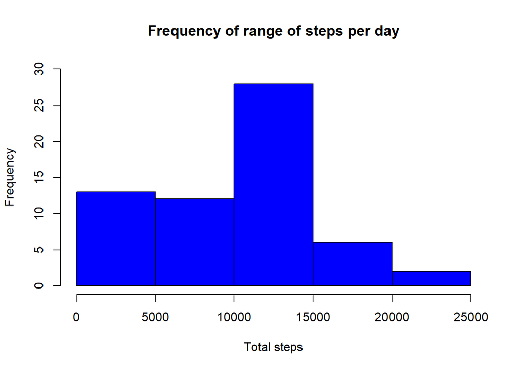

```r
data_hist<- data$x
hist(data_hist,
     main="Frequency of range of steps per day",
     xlab="Total steps",
     col="blue",
     ylim = c(0,30),
)
```

### Calculate and report the mean and median of the total number of steps taken per day

```r
mean_steps <- round(mean(data$x, na.rm = TRUE))
print(paste("The mean is: ", mean_steps))
```

```
## [1] "The mean is:  9354"
```

```r
median_steps <- round(median(data$x, na.rm = TRUE))
print(paste("The median is: ", median_steps))
```

```
## [1] "The median is:  10395"
```

## What is the average daily activity pattern?

```r
interval_mean <-aggregate(x = activity_data$steps,
                          by = list(activity_data$interval),
                          FUN = mean, na.rm=TRUE)
head(interval_mean)
```

```
##   Group.1         x
## 1       0 1.7169811
## 2       5 0.3396226
## 3      10 0.1320755
## 4      15 0.1509434
## 5      20 0.0754717
## 6      25 2.0943396
```

## Time series plot

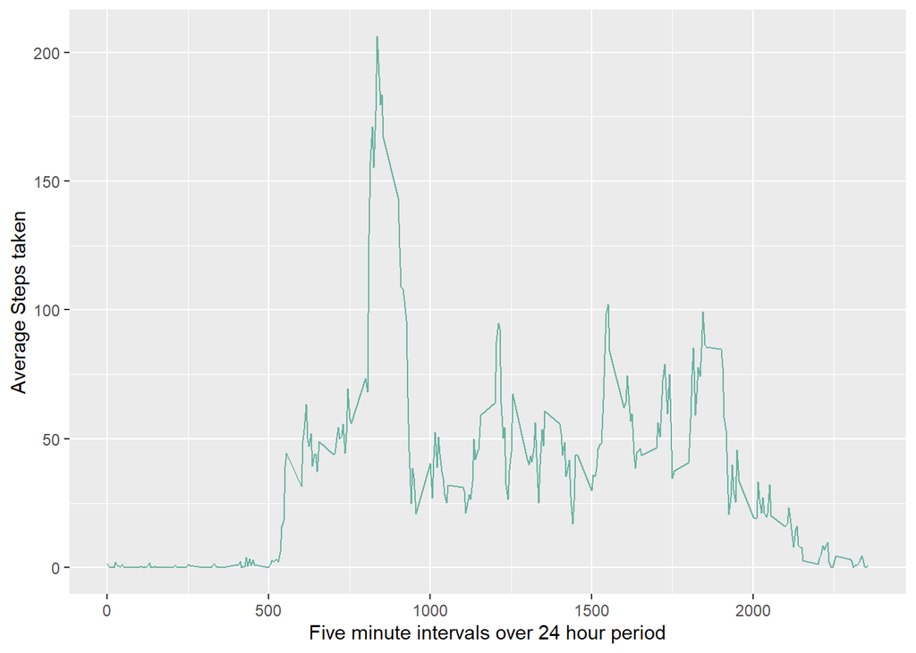

```r
interval_meanplot <- ggplot(interval_mean, aes(x=Group.1, y=x)) +
  geom_line(color="#69b3a2") +
  xlab("Five minute intervals over 24 hour period") +
  ylab("Average Steps taken")
interval_meanplot
```

### 5 min interval with the highest step average

```r
interval_avg <-interval_mean[which.max(interval_mean$x),]
print(paste("The highest average number of steps for any 5 minute interval: ", interval_avg$Group.1))
```

[output not shown]

## Imputing missing values

Note that there are a number of days/intervals where there are missing values. The presence of missing days may introduce bias into some calculations or summaries of the data.

### Calculate and report the total number of missing values in the dataset

```r
sapply(activity_data, function(x) sum(is.na(x)))
```

```
##    steps     date interval
##     2304        0        0
```

### Impute with mean value

```r
df_imputed <- ddply(activity_data, "interval", mutate, imputed.value = impute(steps, mean))
dfIm <- df_imputed %>%
          mutate(steps1 = coalesce(steps, imputed.value))

drop_col <- c("steps","imputed.value")
new_df<-dfIm[ , !(names(dfIm) %in% drop_col)]
head(new_df)
```

```
##         date interval    steps1
## 1 2012-10-01        0  1.716981
## 2 2012-10-02        0  0.000000
## 3 2012-10-03        0  0.000000
## 4 2012-10-04        0 47.000000
## 5 2012-10-05        0  0.000000
## 6 2012-10-06        0  0.000000
```

### Histogram of step frequency

```r
new_dfIm <-aggregate(x = new_df$steps1,
                 by = list(new_df$date),
                 FUN = sum)

dfIMhist<- new_dfIm$x
head(dfIMhist)
```

```
## [1] 10766.19   126.00 11352.00 12116.00 13294.00 15420.00
```

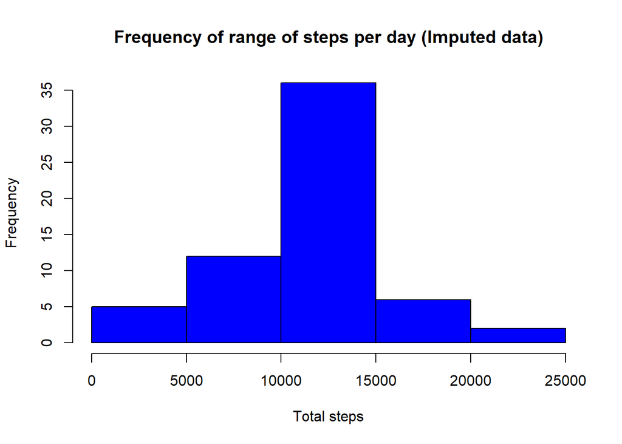

```r
hist(dfIMhist,
     main="Frequency of range of steps per day (Imputed data)",
     xlab="Total steps",
     col="blue",
)
```

### Mean and median number of all steps per day

```r
mean_steps_new_df <- round(mean(new_dfIm$x))
print(paste("The mean is: ", mean_steps_new_df))
```

```
## [1] "The mean is:  10766"
```

```r
median_steps_new_df <- round(median(new_dfIm$x))
print(paste("The median is: ", median_steps_new_df))
```

```
## [1] "The median is:  10766"
```

## What is the impact of imputing missing data on the estimates of the total daily number of steps?

Imputing the NA’s values increases the mean of steps taken per day from 9354 to 10766 and the median from 10395 to 10766. Using imputed data allows for the data containing NA’s to be used in the analysis, however caution should be taken as the imputed values may bias the analysis.

## Are there differences in activity patterns between weekdays and weekends?

```r
new_df1 <-new_df

new_df1$date <- as.Date(new_df1$date)
new_df1$day <- weekdays(new_df1$date)

new_df1$weekday_end <- ifelse(new_df1$day == c("Saturday","Sunday"), "Weekend","Weekday")

week_df <- filter(new_df1, new_df1$weekday_end == "Weekday")
head(week_df)
```

```
##         date interval    steps1       day weekday_end
## 1 2012-10-01        0  1.716981    Monday     Weekday
## 2 2012-10-02        0  0.000000   Tuesday     Weekday
## 3 2012-10-03        0  0.000000 Wednesday     Weekday
## 4 2012-10-04        0 47.000000  Thursday     Weekday
## 5 2012-10-05        0  0.000000    Friday     Weekday
## 6 2012-10-06        0  0.000000  Saturday     Weekday
```

```r
Weekend_df <- filter(new_df1, new_df1$weekday_end == "Weekend")
head(Weekend_df)
```

```
##         date interval   steps1      day weekday_end
## 1 2012-10-13        0 0.000000 Saturday     Weekend
## 2 2012-10-14        0 0.000000   Sunday     Weekend
## 3 2012-10-27        0 0.000000 Saturday     Weekend
## 4 2012-10-28        0 0.000000   Sunday     Weekend
## 5 2012-11-10        0 1.716981 Saturday     Weekend
## 6 2012-11-11        0 0.000000   Sunday     Weekend
```

### Create df for weekdays

```r
week_df_mean <-aggregate(x = week_df$steps1,
                          by = list(week_df$interval),
                          FUN = mean)

week_df_mean$weekday_end <- "weekday"
colnames(week_df_mean) <- c("interval", "mean_steps","Day")
head(week_df_mean)
```

```
##   interval mean_steps     Day
## 1        0 1.94375222 weekday
## 2        5 0.38447846 weekday
## 3       10 0.14951940 weekday
## 4       15 0.17087932 weekday
## 5       20 0.08543966 weekday
## 6       25 2.37095052 weekday
```

### Create df for weekends

```r
Weekend_df_mean <-aggregate(x = Weekend_df$steps1,
                         by = list(Weekend_df$interval),
                         FUN = mean)

Weekend_df_mean$weekday_end <- "Weekend"
colnames(Weekend_df_mean) <- c("interval", "mean_steps","Day")
head(Weekend_df_mean)
```

```
##   interval  mean_steps     Day
## 1        0 0.214622642 Weekend
## 2        5 0.042452830 Weekend
## 3       10 0.016509434 Weekend
## 4       15 0.018867925 Weekend
## 5       20 0.009433962 Weekend
## 6       25 0.261792453 Weekend
```

### Join df’s for time series plots

```r
joined_df <- rbind(week_df_mean, Weekend_df_mean)  #UP TO HERE
head(joined_df)
```

```
##   interval mean_steps     Day
## 1        0 1.94375222 weekday
## 2        5 0.38447846 weekday
## 3       10 0.14951940 weekday
## 4       15 0.17087932 weekday
## 5       20 0.08543966 weekday
## 6       25 2.37095052 weekday
```

### Time series plots for weekdays and weekends

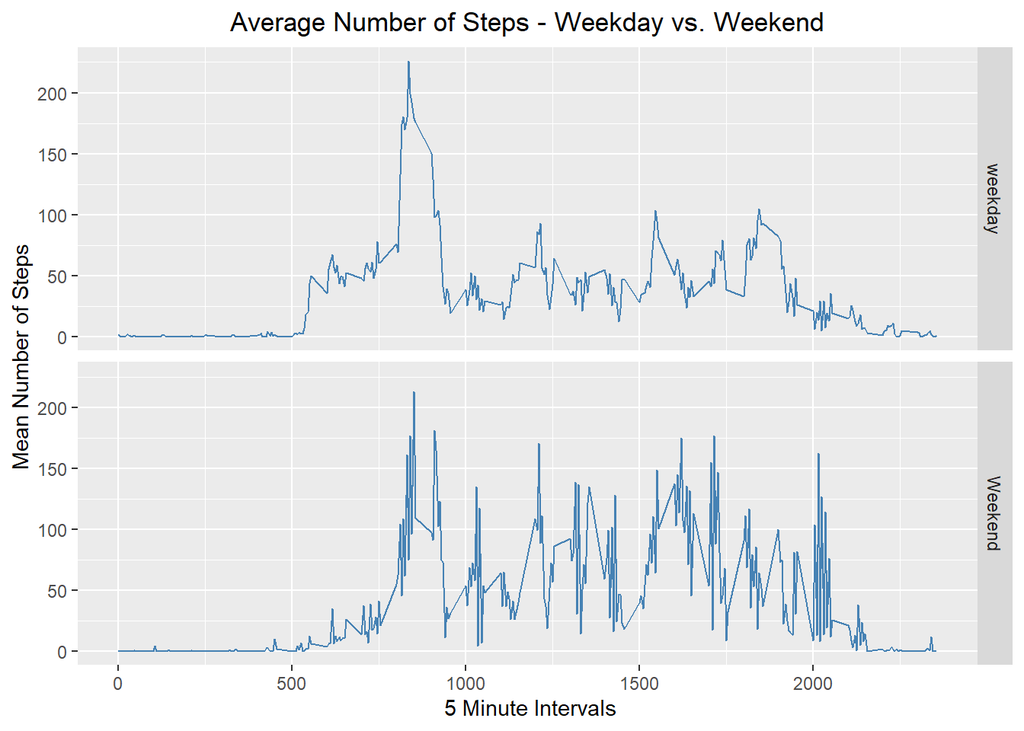

```r
g <- ggplot (joined_df, aes (x=interval, y=mean_steps))
g + geom_line(color="steelblue") + facet_grid (Day~.) +
  labs(y = "Mean Number of Steps") + labs(x = " 5 Minute Intervals") +
  ggtitle("Average Number of Steps - Weekday vs. Weekend") +
  theme(plot.title = element_text(hjust = 0.5))
```